# Part A: Data Cleaning & Exploratory Analysis

```python
import matplotlib.pyplot as plt
import pandas as pd
%matplotlib inline
import numpy as np
import seaborn as sns

from sklearn.model_selection import train_test_split

from sklearn.linear_model import LinearRegression
from sklearn.metrics import mean_squared_error, r2_score, explained_variance_score
```

```python
# Step 1: Import dataset
data = pd.read_csv('bottle.csv')
```

```python
# Verify that the shape is: (864863, 74)
print("Shape of dataset:", data.shape)
```

```
Shape of dataset: (864863, 74)
```

```python
# Step 2: Limit dataset to specified columns and remove NaN and NA values
columns_to_keep = ['T_degC', 'Salnty', 'STheta']
data = data[columns_to_keep].dropna()
```

```python
# Verify the new shape is (812174, 3)
print("Shape after removing NaN and NA values:", data.shape)
```

```
Shape after removing NaN and NA values: (812174, 3)
```

```python
# Step 3: Build scatter plots using Matplotlib
data.head(5)
```

|  | T_degC | Salnty | STheta |
| --- | --- | --- | --- |
| 0 | 10.50 | 33.440 | 25.649 |
| 1 | 10.46 | 33.440 | 25.656 |
| 2 | 10.46 | 33.437 | 25.654 |
| 3 | 10.45 | 33.420 | 25.643 |
| 4 | 10.45 | 33.421 | 25.643 |

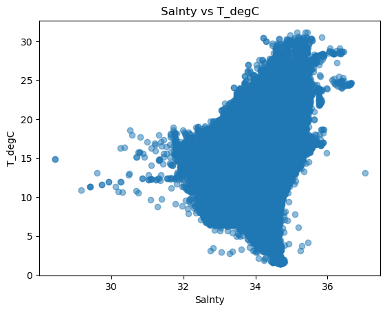

```python
# Scatter plot: Salnty vs T_degC
plt.scatter(data['Salnty'], data['T_degC'], alpha=0.5)
plt.title('Salnty vs T_degC')
plt.xlabel('Salnty')
plt.ylabel('T_degC')
```

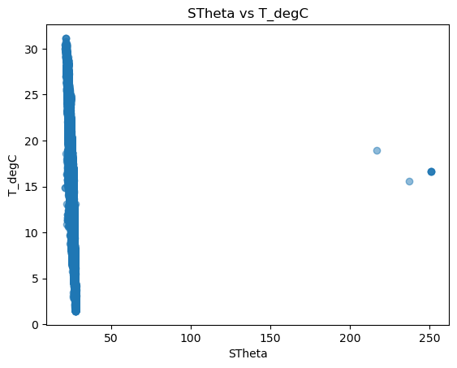

```python
# Scatter plot: STheta vs T_degC
plt.scatter(data['STheta'], data['T_degC'], alpha=0.5)
plt.title('STheta vs T_degC')
plt.xlabel('STheta')
plt.ylabel('T_degC')
```

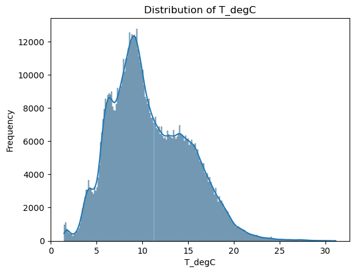

```python
# Step 4: Build distribution plot using Seaborn
# Distribution of T_degC (hint: distplot will be helpful here)
sns.histplot(data['T_degC'], kde=True)
plt.title('Distribution of T_degC')
plt.xlabel('T_degC')
plt.ylabel('Frequency')
plt.show()
```

```python
# Step 5: Remove outliers from STheta column
data_clean = data[(data['STheta'] <= 50)]
```

```python
# Verify shape of clean data
#  Shape for clean data will be: (812168, 3)
print("Shape of clean data after removing outliers:", data_clean.shape)
```

```
Shape of clean data after removing outliers: (812168, 3)
```

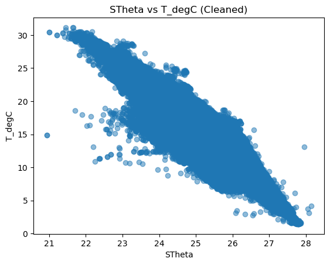

```python
# Step 6: Plot STheta vs T_degC again
plt.scatter(data_clean['STheta'], data_clean['T_degC'], alpha=0.5)
plt.title('STheta vs T_degC (Cleaned)')
plt.xlabel('STheta')
plt.ylabel('T_degC')
plt.show()
```

```python
# Step 6 looks better than Step 3b since we exclude obvious and extreme outliers from dataset
```

# Part B: Train & Test Split

```python
# Define features (X) and target (y)
X = data_clean[['Salnty', 'STheta']]
y = data_clean['T_degC']

# Perform train-test split
X_train, X_test, y_train, y_test = train_test_split(X, y, test_size=0.2, random_state=42)

# Print shapes to verify
print("Shape of X_train:", X_train.shape)
print("Shape of X_test:", X_test.shape)
print("Shape of y_train:", y_train.shape)
print("Shape of y_test:", y_test.shape)
```

```
Shape of X_train: (649734, 2)
Shape of X_test: (162434, 2)
Shape of y_train: (649734,)
Shape of y_test: (162434,)
```

# Part C: Linear Regression Using Normal Equation - Coded In Python

# From Ordinary Least Squares (OLS)

```python
# Step 1: Build the normal equation and fit using training data (X_train & y_train)

# Add intercept value of 1 for every observation in X_train
X_train_with_intercept = np.column_stack((np.ones(len(X_train)), X_train))

# Calculate the coefficients using the normal equation
theta = np.linalg.inv(X_train_with_intercept.T.dot(X_train_with_intercept)).dot(X_train_with_intercept.T).dot(y_train)
```

```python
X_train_with_intercept
```

```
array([[ 1.    , 33.5593, 24.7422],
       [ 1.    , 33.485 , 24.089 ],
       [ 1.    , 33.453 , 25.586 ],
       ...,
       [ 1.    , 34.22  , 26.347 ],
       [ 1.    , 34.044 , 26.409 ],
       [ 1.    , 33.47  , 24.458 ]])
```

```python
X_train
```

|  | Salnty | STheta |
| --- | --- | --- |
| 838571 | 33.5593 | 24.7422 |
| 642296 | 33.4850 | 24.0890 |
| 793189 | 33.4530 | 25.5860 |
| 621313 | 34.3240 | 27.0240 |
| 197459 | 34.0810 | 26.8900 |
| ... | ... | ... |
| 297383 | 33.6140 | 25.7070 |
| 405745 | 34.6620 | 27.7340 |
| 167579 | 34.2200 | 26.3470 |
| 722499 | 34.0440 | 26.4090 |
| 157273 | 33.4700 | 24.4580 |

649734 rows × 2 columns

```python
len(X_train)
```

```
649734
```

```python
# Step 2: Print out the coefficients
print("Coefficients:", theta)
```

```
Coefficients: [35.64451188  3.11151204 -5.03907257]
```

```python
# Step 3: Predict T_degC for the test data using the fitted values

# Add intercept value of 1 for every observation in X_test
X_test_with_intercept = np.column_stack((np.ones(len(X_test)), X_test))

# Predict T_degC for the test data
y_pred = X_test_with_intercept.dot(theta)
```

```python
np.amax(y_pred)
```

```
36.71891556764794
```

```python
np.amin(y_pred)
```

```
3.52654944583801
```

```python
# Step 4: Calculate metrics for the test data

# Mean squared error
mse = np.mean((y_pred - y_test) ** 2)

# R-squared
ss_res = np.sum((y_test - y_pred) ** 2)
ss_tot = np.sum((y_test - np.mean(y_test)) ** 2)
r_squared = 1 - (ss_res / ss_tot)

# Explained variance.
# Explained variation measures the proportion to which a mathematical model accounts for the variation of a given data set.
explained_variance = 1 - (np.var(y_test - y_pred) / np.var(y_test))

# Print metrics
print("Mean Squared Error:", np.round(mse, 2))
print("R-squared:", np.round(r_squared, 2))
print("Explained Variance:", np.round(explained_variance, 2))
```

```
Mean Squared Error: 0.23
R-squared: 0.99
Explained Variance: 0.99
```

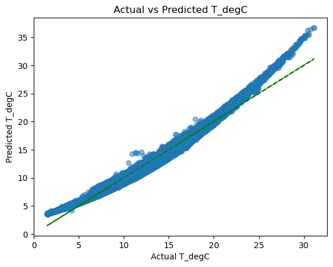

```python
# Step 5: Create scatterplot of actual versus predicted values for T_degC
plt.scatter(y_test, y_pred, alpha=0.5)
plt.plot(y_test, y_test, color='green', linestyle='--')  # Plot y = x line for reference
plt.title('Actual vs Predicted T_degC')
plt.xlabel('Actual T_degC')
plt.ylabel('Predicted T_degC')
plt.show()
```

# Part D: Using sklearn API

# The LinearRegression class is based on the scipy.linalg.lstsq() function (the name stands for "least squares")

```python
# Step 1: Create an instance of the LinearRegression class and fit using X_train & y_train
lin_reg = LinearRegression()
lin_reg.fit(X_train, y_train)
```

```
LinearRegression()
```

```python
# Step 2: Print out the coefficients (including the intercept)
print("Intercept:", lin_reg.intercept_)
print("Coefficients:", lin_reg.coef_)
```

```
Intercept: 35.644511878048576
Coefficients: [ 3.11151204 -5.03907257]
```

```python
# Step 3: Predict T_degC for the test data using the fitted values
y_pred_sklearn = lin_reg.predict(X_test)
```

```python
# Step 4: Calculate metrics for the test data
mse_sklearn = mean_squared_error(y_test, y_pred_sklearn)
r_squared_sklearn = r2_score(y_test, y_pred_sklearn)
explained_variance_sklearn = explained_variance_score(y_test, y_pred_sklearn)
```

```python
# Print metrics
print("Mean Squared Error (sklearn):", np.round(mse_sklearn, 2))
print("R-squared (sklearn):", np.round(r_squared_sklearn, 2))
print("Explained Variance (sklearn):", np.round(explained_variance_sklearn, 2))
```

```
Mean Squared Error (sklearn): 0.23
R-squared (sklearn): 0.99
Explained Variance (sklearn): 0.99
```

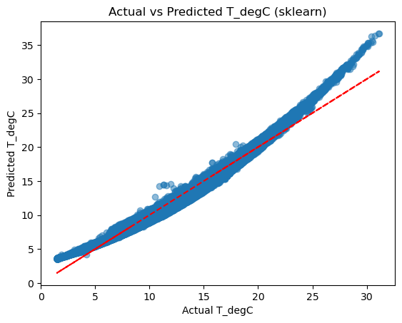

```python
# Step 5: Create scatterplot of actual versus predicted values for T_degC
plt.scatter(y_test, y_pred_sklearn, alpha=0.5)
plt.plot(y_test, y_test, color='red', linestyle='--')  # Plot y = x line for reference
plt.title('Actual vs Predicted T_degC (sklearn)')
plt.xlabel('Actual T_degC')
plt.ylabel('Predicted T_degC')
plt.show()
```

# Part E: Conceptual Questions

### 1. Why is it important to have a test set

The test set simulates real-world data that the model is likely to encounter in production. By assessing the model's performance on previously unseen examples, we can gauge its ability to generalize and make accurate predictions on new, unseen data. The test error from test set is the generalization error.

### 3. How might we improve the fit of our models from Part C & D?

### Note: There are lots of possible answers to this section - just describe one in detail.

Outlier Detection and Removal: Identify and remove outliers from the dataset that may be adversely affecting model performance. We only looked at the outliers from STheta (density of water) vs T_degC. We also need to look at outliers from Salnty (salinity of water) vs T_degC. Standardization: Scale the features to have zero mean and unit variance (standardization) to improve convergence and stability of optimization algorithms.

### 4. As we move further into Machine Learning, we will need to continually consider the bias-variance tradeoff. Explain what bias is and what variance is in regards to the bias-variance tradeoff.

Mathematically

bias = training set error

variance = (train - test) set error

Bias: Bias refers to the error introduced by approximating a real-world problem with **a simplified model**. It represents the difference between the average prediction of the model and the true value we are trying to predict. A high bias model tends to underfit the data, meaning it oversimplifies the underlying relationships between variables and performs poorly on both the training and test datasets.

Variance: Variance measures the model's sensitivity to small fluctuations or noise in the training data. It represents the **amount by which the model's predictions would change if trained on different subsets of the data**. A high variance model tends to overfit the training data, capturing noise in the data rather than the underlying patterns, and performs well on the training dataset but poorly on the test dataset.

In brief, bias is the error introduced by the simplifying assumptions of the model, while variance is the error introduced by the model's sensitivity to noise in the training data. The bias-variance tradeoff refers to the delicate balance between these two sources of error: reducing bias typically increases variance and vice versa. The goal is to find the optimal balance that **minimizes the model's overall error on unseen data**.

### 5. In a linear regression model, how might we reduce bias?

Reducing bias in a linear regression model involves increasing model complexity, incorporating more relevant features, and relaxing assumptions to better capture the underlying patterns in the data.

### 6. In a linear regression model, how might we reduce variance?

Reducing variance in a linear regression model involves techniques that aim to prevent overfitting to the training data and encourage generalization to unseen data.

Regularization: Regularization techniques like Ridge Regression and Lasso Regression add a penalty term to the loss function, which discourages large coefficients. This helps reduce variance by preventing the model from fitting the noise in the training data too closely.

Feature Selection: Selecting only the most relevant features and discarding irrelevant or redundant ones can reduce variance by simplifying the model and preventing overfitting to noisy or irrelevant features.

Cross-Validation: Using techniques like k-fold cross-validation allows the model to be trained and evaluated on multiple subsets of the data. This helps estimate the model's performance more accurately and reduces the likelihood of overfitting to a specific training set.

Ensemble Methods: Ensemble methods like Random Forests and Gradient Boosting combine multiple weak learners (e.g., decision trees) to create a more robust and generalizable model. By averaging predictions from multiple models, ensemble methods can reduce variance and improve performance.

Early Stopping: In iterative optimization algorithms like Gradient Descent, monitoring the model's performance on a validation set and stopping training when performance starts to degrade can prevent overfitting and reduce variance.

Simplifying the Model: Using simpler models with fewer parameters can reduce variance by limiting the model's capacity to fit the training data too closely. For example, using linear regression instead of polynomial regression can reduce variance at the cost of potentially increased bias.

Increasing Training Data: Increasing the size of the training dataset can help the model generalize better to unseen data by providing more diverse examples for training. This can reduce variance by exposing the model to a wider range of scenarios and reducing the impact of noise in the training data.

Notes

https://github.com/ageron/handson-ml/blob/master/04_training_linear_models.ipynb

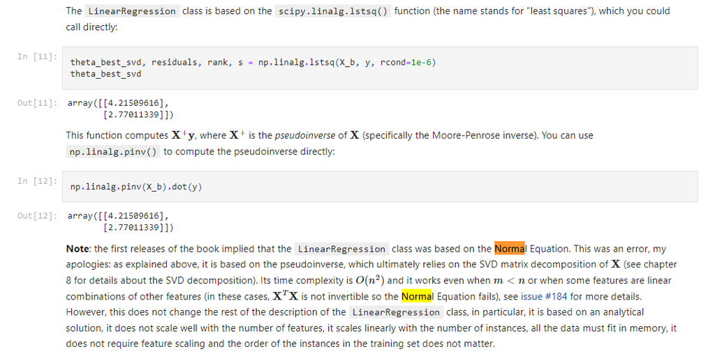

The Normal Equation provides an analytical solution to the linear regression problem by directly computing the coefficients based on the training data. While it's a straightforward approach for small datasets, it can be computationally expensive and numerically unstable for large datasets or datasets with multicollinearity.